# Regression Comparisons

11/4/2016

## Credit Card Debt

## Introduction

Based on Chapter 6 *Linear Model Selection and Regularization* of **An Introduction to Statistical Learning** by Gareth James, Daniela Witten, Trevor Hastie and Robert Tibshirani

Credit data set:

- 400 observations with 11 variables
- Quantitative variables: balance, age, cards, education, income, limit, and rating
- Qualitative variables: gender, student, married, and ethnicity

## Data

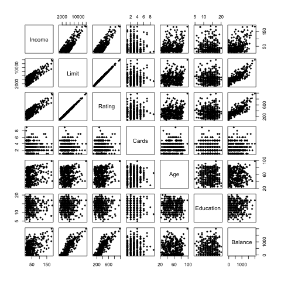

Scatterplot Matrix

## Data - Correlation Matrix

|  | Income | Limit | Rating | Cards | Age | Education | Balance |
| --- | --- | --- | --- | --- | --- | --- | --- |
| **Income** | 1 | 0.7921 | 0.7914 | -0.0183 | 0.1753 | -0.0277 | 0.4637 |
| **Limit** |  | 1 | 0.9969 | 0.0102 | 0.1009 | -0.0235 | 0.8617 |
| **Rating** |  |  | 1 | 0.0532 | 0.1032 | -0.0301 | 0.8636 |
| **Cards** |  |  |  | 1 | 0.0429 | -0.0511 | 0.0865 |
| **Age** |  |  |  |  | 1 | 0.0036 | 0.0018 |
| **Education** |  |  |  |  |  | 1 | -0.0081 |
| **Balance** |  |  |  |  |  |  | 1 |

## Regressions

## Models

To find the best model for prediction, following regression models were considered:

- Ordinary Least Squares Regression (OLS)
- Ridge Regression (RR)
- Lasso Regression (LR)
- Principal Components Regression (PCR)
- Partial Least Squares Regression (PLSR)

## Ordinary Least Squares Regression (OLS)

- Gauss-Markov theorem: OLS is the best linear unbiased estimator
- correlated regressors will destabilize \(\beta\) estimates

## Ridge Regression (RR)

- variation of the minimization in OLS Regression
- added constraint of \(||\beta||^2_2 < c^2\)
- takes multicollinearity into account and does automatics parameter selection \(min \beta\) \(||y-A\beta||^2_2 + \lambda||\beta||^2_2\)
- \(\lambda\) is known as a tuning parameter, and \(\lambda||\beta||^2_2\) is called a *shrinkage penalty*

## Lasso Regression (LR)

- variation of the minimization in OLS Regression
- added constraint of \(||\beta||_1 < c\)
- parameter shrinkage through feature selection (sparsify regressors/predictors)
- variable selection \(min \beta\) \(||y-A\beta||^2_2 + \lambda||\beta||_1\)

## Principal Components Regression (PCR)

- dimensionality reduction method
- maximizes the the variability in the data set

## Partial Least Squares Regression (PLSR)

- dimensionality reduction method
- takes into account of the classes and tries to reduce the dimension while maximizing the separation of classes

## Analysis

## Method

1. Standardize Data (Mean-centering and dummy variables)
2. Randomly generate test and train set indices
3. Use cross validation in each regression to find the best model
4. Perfom each regression on the train set to obtain coefficients
5. Used coefficients to predict balance for test set
6. Obtain MSE from the test set
7. Obtain official coefficients on entire set using best model
8. Compare the coefficients and test MSE

## Results - Coefficient Comparisons

|  | OLS | Ridge | Lasso | PCR | PLS |
| --- | --- | --- | --- | --- | --- |
| **(Intercept)** | 8.236e-16 | 0 | 0 | NA | NA |
| **Income** | -0.5982 | -0.5687 | -0.5517 | -0.5982 | -0.5989 |
| **Limit** | 0.9584 | 0.7187 | 0.925 | 0.9584 | 0.6849 |
| **Rating** | 0.3825 | 0.5931 | 0.3679 | 0.3825 | 0.657 |
| **Cards** | 0.05286 | 0.04425 | 0.045 | 0.05286 | 0.04137 |
| **Age** | -0.02303 | -0.02538 | -0.01666 | -0.02303 | -0.02282 |

## Results - Coefficient Comparisons

|  | OLS | Ridge | Lasso | PCR | PLS |
| --- | --- | --- | --- | --- | --- |
| **Education** | -0.007469 | -0.00588 | 0 | -0.007469 | -0.005095 |
| **GenderFemale** | -0.01159 | -0.01068 | 0 | -0.01159 | -0.01239 |
| **StudentYes** | 0.2782 | 0.2732 | 0.2668 | 0.2782 | 0.277 |
| **MarriedYes** | -0.009054 | -0.01103 | 0 | -0.009054 | -0.01003 |
| **EthnicityAsian** | 0.01595 | 0.01638 | 0 | 0.01595 | 0.01459 |
| **EthnicityCaucasian** | 0.01101 | 0.01101 | 0 | 0.01101 | 0.00865 |

## Results - Coefficient Comparisons

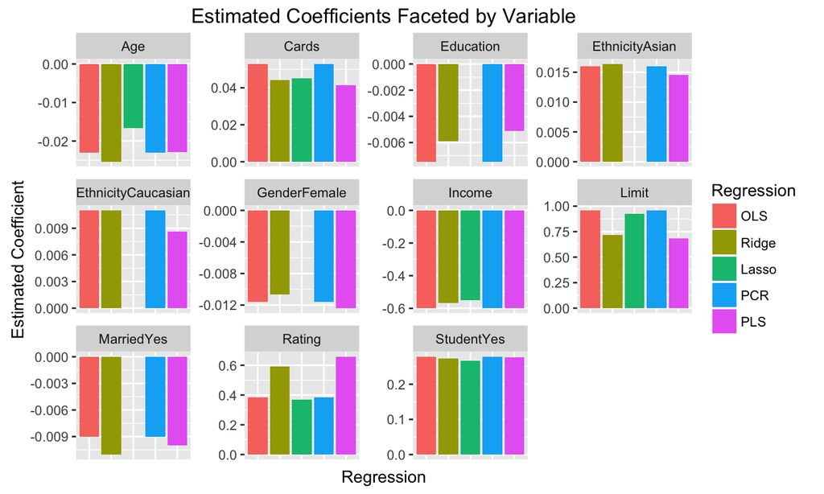

## Results - Coefficient Comparisons

Findings:

## Results - MSE Comparison

Table continues below

| Regression | OLS | Ridge | Lasso |
| --- | --- | --- | --- |
| MSE | 0.0555499944772785 | 0.0556070961283462 | 0.0551517479146706 |

| PCR | PLS |
| --- | --- |
| 0.0555499944772785 | 0.0560468725801607 |

## Prediction Plot - Ridge

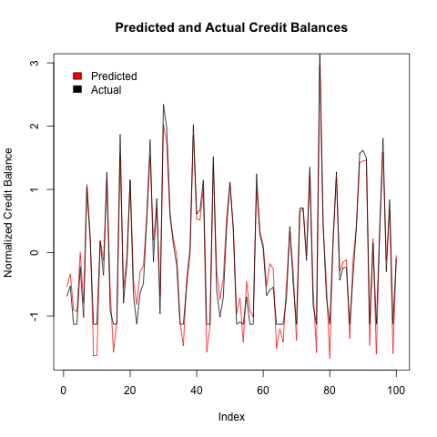

Prediction for Ridge

## Prediction Plot - Lasso

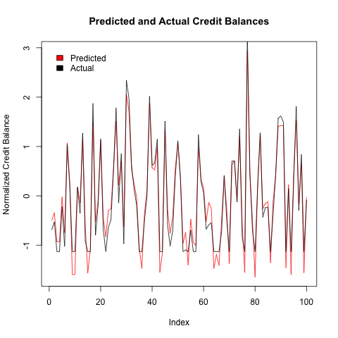

Prediction for Lasso

## Conclusion

- Although OLS is the best linear unbiased estimator, lasso regression yielded the least MSE in the credit data set.
- Using this model, it was found that characteristics such as income, credit limit, credit rating, number of cards held by the individual, age, and student status have the best prediciton for credit debt.